# Homework 2, Group G

Abdalghani, Demirbilek, Dorigo, Miolato

Spring 2020

## Laboratory 2

### Exercise 1

- Check the biased nature of $s_b^2$ via MC simulation, generating $n=10$ iid values from a normal distribution. Plot also $s^2$ and comment the difference.

*solution :*

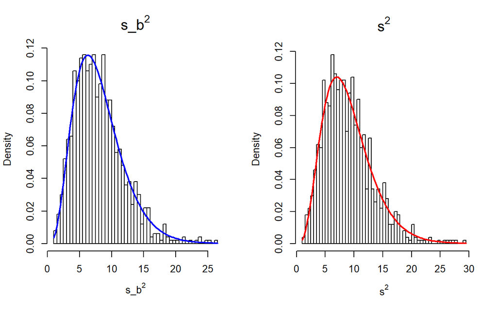

```r
rep <- 1000
n <- 10
mu <- 5
sigma <- 3

samples <- array(0, c(rep,n))
statistics <- array(0,c(rep,2))


for (i in 1:rep){
  samples[i,] <- rnorm(n,mu,sigma)
  statistics[i,1] <- var(samples[i,])
  statistics[i,2] <- statistics[i,1]*(n-1)/n
}

par (mfrow=c(1,2), oma=c(0,0,0,0))
hist(statistics[,2], breaks= 40, probability = TRUE,
xlab=expression(s_b^2), main= bquote(s_b^2), cex.main=1.5)
curve(((n)/sigma^2) * dchisq(x * ((n)/sigma^2), df = n - 1),
add = TRUE, col="blue", lwd=2, main="N(0,1)")

hist(statistics[ ,1], breaks= 40, probability = TRUE,
xlab=expression(s^2), main= bquote(s^2), cex.main=1.5)
curve(((n-1)/sigma^2) * dchisq(x * ((n-1)/sigma^2), df = n - 1),
add = TRUE, col="red", lwd=2, main="N(0,1)")
```

```r
#is s2 correct?
mean(statistics[,1])
```

```
## [1] 8.93864
```

```r
sigma**2
```

```
## [1] 9
```

```r
#is sb2 correct?
mean(statistics[,2])
```

```
## [1] 8.044776
```

```r
sigma**2
```

```
## [1] 9
```

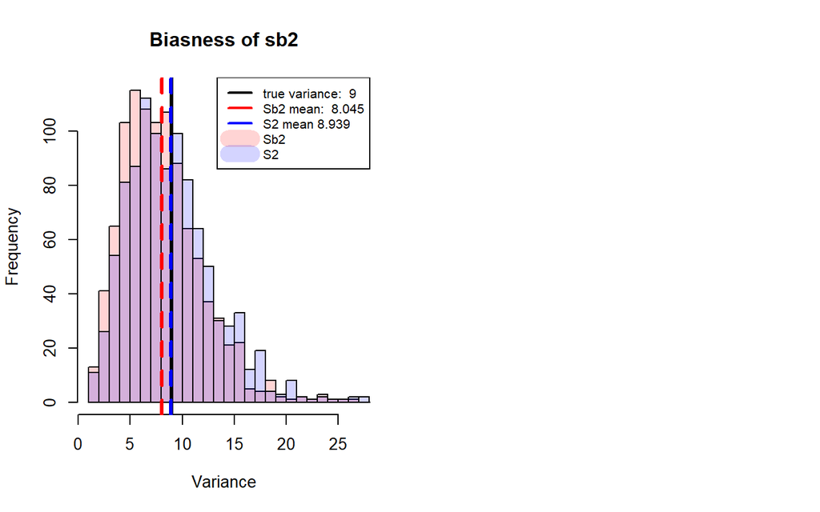

```r
#plot s2 observed, sb2 observed and true value
{
hist(statistics[,2],breaks=20,col=rgb(1,0,0,1/6),main="Biasness of sb2",xlab="Variance")
hist(statistics[,1],breaks=20,add=TRUE,col=rgb(0,0,1,1/6))
abline(v=sigma**2,lwd=3)
abline(v=mean(statistics[,1]),col=4,lty=2,lwd=3)
abline(v=mean(statistics[,2]),col=2,lty=2,lwd=3)
legend("topright", legend=c(paste("true variance: ",sigma**2), paste("Sb2 mean: ",round(mean(statistics[,2]),3)),paste("S2 mean",round(mean(statistics[,1]),3)),"Sb2","S2"),col=c("black", "red","blue",rgb(1,0,0,1/6),col=rgb(0,0,1,1/6)), lty=c(1,1,1,2,2),lwd=c(2,2,2,14,14), cex=0.8)
}
```

Here We’ve plotted the sample distribution of Sb2 and S2. The black line indicates the true value of the variance. The blue dashed line is the mean of $s^2$ while the red dashed line is the mean of $s_b^2$. I can see that $s_b^2$ is a biased estimator of the variance, indeed it underestimates the true variance $\sigma^2$.

### Exercise 2

What happens if a great player decides to join you, now? Try to simulate the data and perform the test again.

By assuming he is a great player, and that his shots along the game will hit the highest points with great probability and the lowest point with low probability. We assign the following hitting probabilities:

-Zone 1 (from 1 to 3 points): p1=1/16;

-Zone 2 (from 4 to 6 points); p2=3/16;

-Zone 3 (from 7 to 9 points); p3=5/16;

-Zone 4 (the highest points in the middle of the target, say 10, 25, 50 points): p4=7/16;

*solution :*

For the first simulation 7 seven players have been considered, 6 with the same probability distribution $p_1=7/16$, $p_2=5/16$, $p_3=3/16$, $p_4=1/16$ and the seventh, greater, player with distribution $p_1=1/16$, $p_2=3/16$, $p_3=5/16$, $p_4=7/16$. For the hypothesis tests a $\alpha=0.05$ significance level has been fixed.

```r
set.seed(343)
n <- 50
K <- 4
M <- 7

y <- apply(matrix(rep(1:K, times=M-1), byrow=TRUE, nrow=6, ncol=K), 1, sample, size=n,
           replace=TRUE, prob =c( 7/16, 5/16, 3/16, 1/16))
observed <- apply(y, 2, table)
expected <- c( n*(7/16), n*(5/16), n*(3/16), n*(1/16))
x2 <- sum((observed-expected)^(2)/expected)
pchisq(x2, df =(K-1)*((M-1)-1), lower.tail =FALSE )
```

```
## [1] 0.7219997
```

As expected, the homogeneity Pearson’s chi-squared test statistic estimated on the players with same distribution, that is 11.424, is not significant since the p-value (roughly 0.72) is higher than the significance level.

```r
y_gp <- sample( 1:K, n, replace=TRUE, prob =c( 1/16, 3/16, 5/16, 7/16))
observed_gp <- table(y_gp)
x2_gp <- sum((cbind(observed,observed_gp)-expected)^(2)/expected)
pchisq(x2_gp, df =(K-1)*(M-1), lower.tail =FALSE )
```

```
## [1] 1.008611e-28
```

Adding to the simulation the great player the test statistic estimated shows a strong evidence (p-value<<0.001) against the $H_0$ null hypothesis of homogeneity among the players, i.e. the great player is much more stronger than other players. \ The second simulation instead of assuming the same distribution for all the initial sixth players, it is randomly uniformly sampled from the vector $(7/16, 5/16, 3/16, 1/16)$.

```r
y_2 <- apply(matrix(rep(1:K, times=M-1), byrow=TRUE, nrow=6, ncol=K), 1, sample, size=50,
            replace=TRUE, sample(c(7/16, 5/16, 3/16, 1/16), prob=rep(1/4,4)))
observed_2 <- apply(y_2, 2, table)

x2_2 <- sum((observed_2-expected)^(2)/expected)
pchisq(x2_2, df =(K-1)*((M-1)-1), lower.tail =FALSE )
```

```
## [1] 8.515396e-87
```

Also in this case the p-value is really small, so the homogeneity hypothesis has to be rejected.

```r
x2_gp_2 <- sum((cbind(observed_2,observed_gp)-expected)^(2)/expected)
pchisq(x2_gp_2, df =(K-1)*(M-1), lower.tail =FALSE )
```

```
## [1] 4.421796e-120
```

Since what has been seen before the test carried out on the first 6 players with the great one is expected not to change the previous conclusion. In deed the p-value is even smaller.

### Exercise 3

Are the Instagram and Twitter account somehow associated? Perform a correlation test, compute the p-value and give an answer. Here is the dataframe.

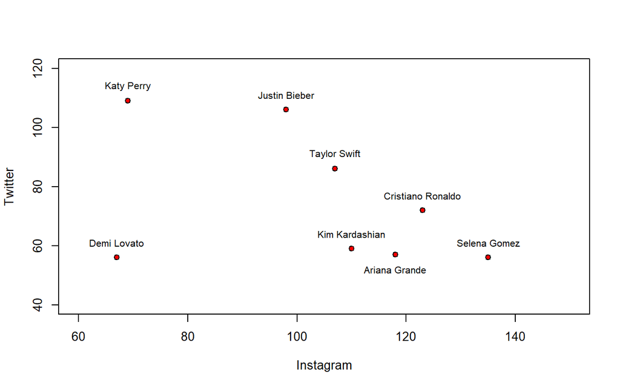

```r
Owners <- c( "Katy Perry", "Justin Bieber", "Taylor Swift", "Cristiano Ronaldo",
                   "Kim Kardashian", "Ariana Grande", "Selena Gomez", "Demi Lovato")
Instagram <- c( 69, 98,107, 123, 110, 118, 135, 67)
Twitter <- c( 109, 106, 86, 72, 59, 57, 56, 56)
plot( Instagram, Twitter, pch=21, bg=2, xlim=c(60, 150), ylim=c(40, 120) )
text( Instagram[-6], Twitter[-6]+5, Owners[-6], cex=0.8 )
text( Instagram[6], Twitter[6]-5, Owners[6], cex=0.8 )
```

*solution :*

```r
library(RColorBrewer)

Instagram <- c( 69, 98,107, 123, 110, 118, 135, 67)
Twitter <- c( 109, 106, 86, 72, 59, 57, 56, 56)

n=length(Instagram)
r=cor(Instagram,Twitter)
r
```

```
## [1] -0.4235845
```

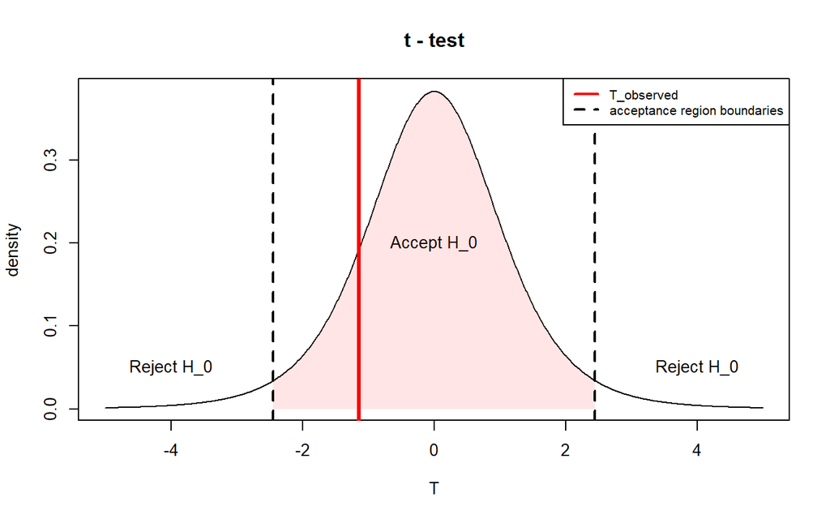

```r
t_obs=r*sqrt((n-2)/(1-r^2))

x <- seq(-5,5,length=1000)
{
plot(x,dt(x,n-2),type="l",xlab="T",ylab="density",main="t - test")
abline(v=t_obs,col=2,lwd=3)


#I fix alpha=0.05 and plot rejection and acceptance region
alpha <- 0.05
r1 <- qt(alpha/2,n-2)
r2 <- qt(1-alpha/2,n-2)
abline(v=r1,lty=2,lwd=2)
abline(v=r2,lty=2,lwd=2)
text (0,0.2, paste("Accept", expression(H_0)))
text(-4,0.05,paste("Reject",expression(H_0)))
text(4,0.05,paste("Reject",expression(H_0)))
legend("topright", legend=c("T_observed", "acceptance region boundaries"),col=c("red","black"),lty=c(1,2),lwd=2, cex=0.8)


alpha <- 0.05
q_inf_95 <- qt(alpha/2, df=n-2)
q_sup_95 <- qt(1-alpha/2, df=n-2)
cord.x <- c(q_inf_95,seq(q_inf_95,q_sup_95,0.01),q_sup_95)
cord.y <- c(0,dt(seq(q_inf_95,q_sup_95,0.01),n-2),0)
polygon(cord.x,cord.y,col=rgb(1,0,0,1/10), border = NA )
}
```

Looking at the plot we can see that we should accept the null hypotesis $H_0: \rho=0$. We can also compute the p-value using as alternative hypotesis the two sided one: $H1: \rho \ne0$

```r
#compute the p-value
p=2*(1-pt(abs(t_obs),n-2))
p
```

```
## [1] 0.2956669
```

Since the p-value is higher than the significance level (0.05), $H_0$ is not rejected so the numbers of followers on Instagram of a person is not linearly correlated with his the number of followers on Twitter.

You may try to perform a different test that just investigates the presence of some kind of association between the variables, i.e. you may try to compute the previous test statistic using the Spearman’s rank correlation coefficient, that is a specific case of Pearson correlation coefficient using ranked variables instead of original variables, that also allows to be computed for ordinal qualitative variables.

```r
rho <- cor(Instagram, Twitter, method="spearman")
t_s <- rho*((n-2)/(1-rho^2))^(1/2)
2*(1-pt(abs(t_s), df=n-2))
```

```
## [1] 0.3992639
```

Even in this case the p-value is higher than the significance level. This is an evidence against the assumption of association between the followers numbers of the two social networks.

### Exercise 4

*solution :*

Log-likelihood function
$$l(\alpha, \beta; y) = nlog(\gamma)-n\log(\beta)+\gamma\sum_{i=1}^{n}{\log(y_i)}-\sum_{i=1}^{n}{\frac{y_i}{\beta}}$$

First derivatives of log-likelihood function

$$\begin{align*}
\frac{\partial}{\partial\gamma}{l(\gamma,\beta;y)}&=\frac{n}{\gamma}-n\log(\beta)+\sum_{i=1}^{n}{\log(y_i)}-\sum_{i=1}^{n}{(y_i/\beta)^\gamma\log(y_i/\beta)} \\
\frac{\partial}{\partial\beta}{l(\gamma,\beta;y)}&=-\frac{n\gamma}{\beta}+\frac{\gamma}{\beta^{\gamma+1}}\sum_{i=1}^{n}(y_i)^\gamma \\
\end{align*}$$

Second derivatives of log-likelihood function
$$\begin{align*}
\frac{\partial^2}{\partial^2\gamma}{l(\gamma,\beta;y)}=\frac{\partial}{\partial\gamma}\bigg(\frac{\partial}{\partial\gamma}{l(\gamma,\beta;y)}\bigg)&=\frac{\partial}{\partial\gamma}\bigg(\frac{n}{\gamma}-n\log(\beta)+\sum_{i=1}^{n}{\log(y_i)}-\sum_{i=1}^{n}\bigg(\frac{y_i}{\beta}\bigg)^\gamma\log\bigg(\frac{y_i}{\beta}\bigg)\bigg) \\
&=-\frac{n}{\gamma^2}-\sum_{i=1}^{n}\log\bigg(\frac{y_i}{\beta}\bigg)\frac{\partial}{\partial\gamma}\bigg(\frac{y_i}{\beta}\bigg)^\gamma \\
&=-\frac{n}{\gamma^2}-\sum_{i=1}^{n}\log\bigg(\frac{y_i}{\beta}\bigg)\frac{\partial}{\partial\gamma}\bigg(\exp\bigg(\gamma\log\bigg(\frac{y_i}{\beta}\bigg)\bigg)\bigg)\\
&=-\frac{n}{\gamma^2}-\sum_{i=1}^{n}\log\bigg(\frac{y_i}{\beta}\bigg)\exp\bigg(\gamma\log\bigg(\frac{y_i}{\beta}\bigg)\bigg)\log\bigg(\frac{y_i}{\beta}\bigg) \\
&=-\frac{n}{\gamma^2}-\sum_{i=1}^{n}\bigg(\frac{y_i}{\beta}\bigg)^{\gamma}\log^2\bigg(\frac{y_i}{\beta}\bigg) \\
\\
\frac{\partial^2}{\partial\gamma\partial\beta}{l(\gamma,\beta;y)}=\frac{\partial}{\partial\gamma}\bigg(\frac{\partial}{\partial\beta}{l(\gamma,\beta;y)}\bigg)&=\frac{\partial}{\partial\gamma}\bigg(-\frac{n\gamma}{\beta}+\frac{\gamma}{\beta^{\gamma+1}}\sum_{i=1}^{n}(y_i)^\gamma\bigg) \\
&=\frac{\partial}{\partial\gamma}\bigg(-\frac{n\gamma}{\beta}+\frac{\gamma}{\beta}\sum_{i=1}^{n}\bigg(\frac{y_i}{\beta}\bigg)^\gamma\bigg) \\
&=-\frac{n}{\beta}+\frac{1}{\beta}\sum_{i=1}^{n}\bigg(\frac{y_i}{\beta}\bigg)^\gamma+\frac{\gamma}{\beta}\sum_{i=1}^{n}{\frac{\partial}{\partial\gamma}\bigg(\exp\bigg(\gamma\log\bigg(\frac{y_i}{\beta}\bigg)\bigg)\bigg)} \\
&=-\frac{n}{\beta}+\frac{1}{\beta}\sum_{i=1}^{n}\bigg(\frac{y_i}{\beta}\bigg)^\gamma+\frac{\gamma}{\beta}\sum_{i=1}^{n}{\bigg(\frac{y_i}{\beta}\bigg)^\gamma\log\bigg(\frac{y_i}{\beta}\bigg)} \\
&=-\frac{n}{\beta}+\sum_{i=1}^{n}\bigg(\frac{y_i^{\gamma}}{\beta^{\gamma+1}}\bigg)\bigg(\gamma\log\bigg(\frac{y_i}{\beta}\bigg)+1\bigg) \\
\\
\frac{\partial^2}{\partial^2\beta}{l(\gamma,\beta;y)}=\frac{\partial}{\partial\beta}\bigg(\frac{\partial}{\partial\beta}{l(\gamma,\beta;y)}\bigg)&=\frac{\partial}{\partial\beta}\bigg(-\frac{n\gamma}{\beta}+\frac{\gamma}{\beta^{\gamma+1}}\sum_{i=1}^{n}(y_i)^\gamma\bigg) \\
&=\frac{n\gamma}{\beta^2}-\frac{(\gamma+1)\gamma}{\beta^{\gamma+2}}\sum_{i=1}^{n}(y_i)^\gamma
\end{align*}$$

### Exercise 5

Produce the contour plot for the **quadratic approximation** of the log-likelihood, based on the Taylor series:

$l(\theta)−l(\hat\theta) \approx −\frac{1}{2}(\theta−\hat\theta)^T J(\hat\theta)(\theta−\hat\theta)$.

*solution :*

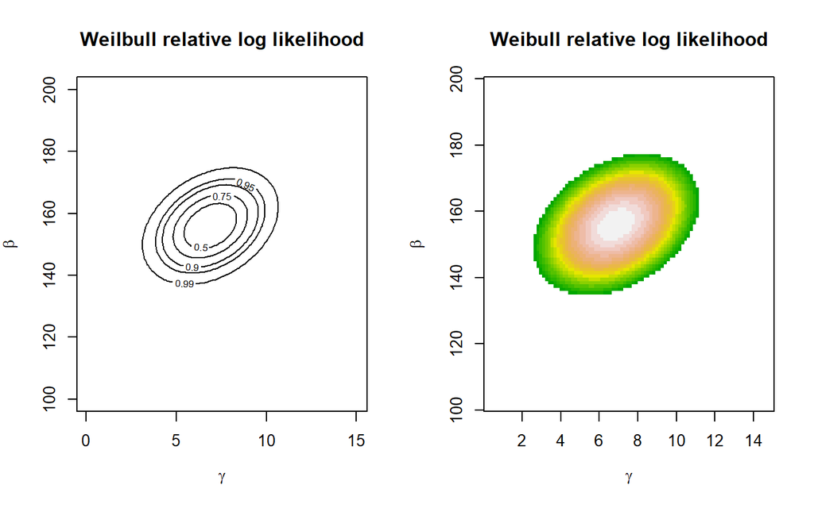

```r
y <- c(155.9, 200.2, 143.8, 150.1,152.1, 142.2, 147, 146, 146,
 170.3, 148, 140, 118, 144, 97)

n <- length(y)

#define parameters grid
gamma <- seq(0.1, 15, length=100)
beta <- seq(100,200, length=100)

parvalues <- expand.grid(gamma,beta)

gammahat<-uniroot(function(x) n/x+sum(log(y))-n*
sum(y^x*log(y))/sum(y^x),
c(1e-5,15))$root
betahat<- mean(y^gammahat)^(1/gammahat)
weib.y.mle<-c(gammahat,betahat)

#observed information matrix
jhat<-matrix(NA,nrow=2,ncol=2)
jhat[1,1]<-n/gammahat^2+sum((y/betahat)^gammahat*
(log(y/betahat))^2)
jhat[1,2]<-jhat[2,1]<- n/betahat-sum(y^gammahat/betahat^(gammahat+1)*
(gammahat*log(y/betahat)+1))
jhat[2,2]<- -n*gammahat/betahat^2+gammahat*(gammahat+1)/
betahat^(gammahat+2)*sum(y^gammahat)

approx <- function(theta){
 return(-0.5*(theta - weib.y.mle) %*% jhat %*% (theta - weib.y.mle))
}

appx <- apply(parvalues, 1, approx)
appx <- matrix(appx, nrow=length(gamma), ncol=length(beta),byrow=F)
conf.levels <- c(0,0.5,0.75,0.9,0.95,0.99)

par (mfrow=c(1,2), oma=c(0,0,0,0))
#contour plot
contour(gamma, beta, appx,
levels=-qchisq(conf.levels, 2)/2,
xlab=expression(gamma),
labels=as.character(conf.levels),
ylab=expression(beta))
title('Weilbull relative log likelihood')

#image
image(gamma,beta,appx,zlim=c(-6,0),
col=terrain.colors(20),xlab=expression(gamma),
ylab=expression(beta))
title('Weibull relative log likelihood')
```

## Core Statistics

### Exercise 3.3

Rewrite the following, replacing the loop with efficient code:

```r
n <- 100000; z <- rnorm(n)
zneg <- 0;j <- 1
for (i in 1:n) {
  if (z[i]<0) {
    zneg[j] <- z[i]
    j <- j + 1
  }
}
```

Confirm that your rewrite is faster but gives the same result.

*solution :*

```r
set.seed(101)
n <- 100000
z <- rnorm(n)
zneg <- 0
zneg2 <- 0
j <- 1

# timing the given function
start <- Sys.time()
for (i in 1:n) {
  if (z[i]<0) {
    zneg[j] <- z[i]
    j <- j + 1
  }
}
end <- Sys.time()
time1 <- end-start

# timing my optimized function
start <- Sys.time()
# in this way I'm copying in zneg2 only the negative values of z
zneg2=z[z<0]
end <- Sys.time()
time2 <- end-start

# check which one is faster
print(paste("Naive function took : " , round(time1, 5)))
```

```
## [1] "Naive function took :  0.031"
```

```r
print(paste("Modified function took : " , round(time2, 5))) #faster
```

```
## [1] "Modified function took :  0.00398"
```

```r
#chech if the results are the same:
summary(zneg)
```

```
##    Min. 1st Qu.  Median    Mean 3rd Qu.    Max.
## -4.2170 -1.1448 -0.6692 -0.7916 -0.3138  0.0000
```

```r
summary(zneg2)
```

```
##    Min. 1st Qu.  Median    Mean 3rd Qu.    Max.
## -4.2170 -1.1448 -0.6692 -0.7916 -0.3138  0.0000
```

Removing the for loop we can see that the elapsed time decrease of one order of magnitude.

### Exercise 3.5

Consider solving the matrix equation $Ax = y$ for $x$, where $y$ is a known n vector and $A$ is a known $n×n$ matrix. The formal solution to the problem is $x = A^{−1}y$, but it is possible to solve the equation directly, without actually forming $A^{−1}$. This question explores this direct solution. Read the help file for $solve$ before trying it.

1. First create an $A$, $x$ and $y$ satisfying $Ax = y$.

*solution :*

```r
set.seed(0);
n <- 1000
A <- matrix(runif(n*n),n,n);
x.true <- runif(n)
y <- A%*%x.true
```

The idea is to experiment with solving $Ax = y$ for $x$, but with a known truth to compare the answer to.

2. Using solve, form the matrix $A^{−1}$ explicitly and then form $x_1 = A^{−1}y$. Note how long this takes. Also assess the mean absolute difference between $x1$ and $x.true$ (the approximate mean absolute ‘error’ in the solution).

*solution :*

```r
start1 <- Sys.time()
A_inv <- solve(A)
x1 <- A_inv%*%y
end1 <- Sys.time()

naive_time = end1-start1
naive_time
```

```
## Time difference of 1.003426 secs
```

```r
mean_abs1 <- mean(abs(x1 - x.true))
mean_abs1
```

```
## [1] 2.956833e-11
```

3. Now use solve to directly solve for $x$ without forming $A^{−1}$. Note how long this takes and assess the mean absolute error of the result.

*solution :*

```r
start2 <- Sys.time()
x2 <- solve(A,y)
end2 <- Sys.time()

opt_time = end2-start2
opt_time
```

```
## Time difference of 0.2068808 secs
```

```r
mean_abs2 <- mean(abs(x2 - x.true))
mean_abs2
```

```
## [1] 1.356142e-12
```

4. What do you conclude?

## Data Analysis and Graphics Using R

### CH3.Exercise 11

The following data represent the total number of aberrant crypt foci (abnormal growths in the colon) observed in seven rats that had been administered a single dose of the carcinogen azoxymethane and sacrificed after six weeks (thanks to RanjanaBird, Faculty of Human Ecology, University of Manitoba for the use of these data): 87 53 72 90 78 85 83 Enter these data and compute their sample mean and variance. Is the Poisson model appropriate for these data? To investigate how the sample variance and sample mean differ under the Poisson assumption, repeat the following simulation experiment several times: x <- rpois(7, 78.3) mean(x); var(x)

*solution :*

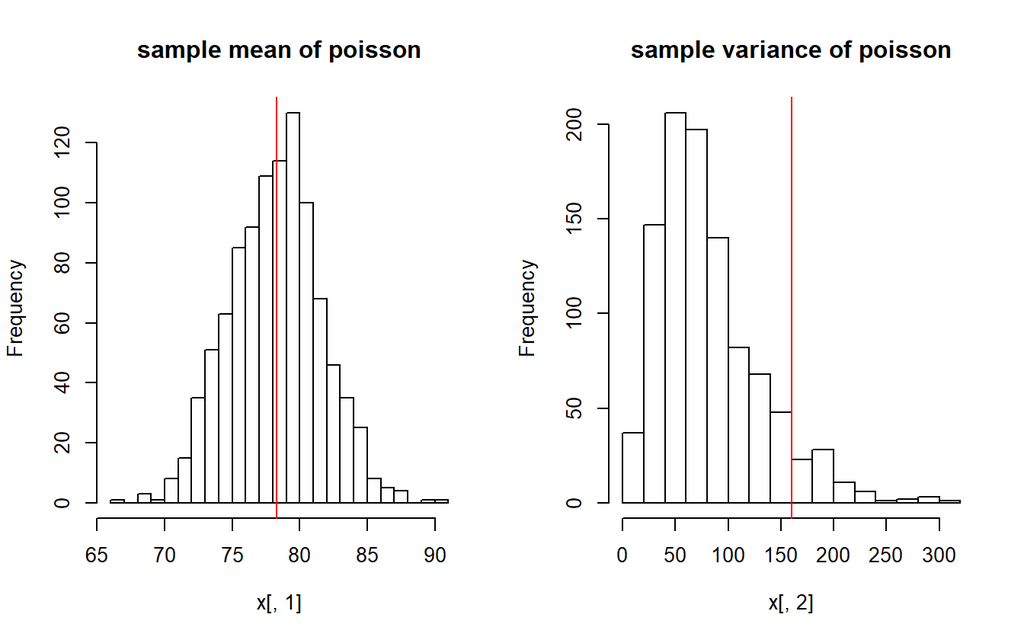

```r
data <- c(87, 53, 72, 90, 78, 85, 83)


rep <- 1000
x <- array(0,c(rep,2))

for (i in 1:rep){
  xx <- rpois(7, 78.3)
  x[i,1] <- mean(xx)
  x[i,2] <- var(xx)
}

# plot histograms of simulated sample mean and sample variance
# plot also a red line for the observed values
par(mfrow=c(1,2))
hist(x[,1],breaks=20,main="sample mean of poisson")
abline(v=mean(data),col=2)
hist(x[,2],breaks=20,main="sample variance of poisson")
abline(v=var(data),col=2)
```

```r
#prob of getting a sample variance bigger than the observed one
sum(x[,2]>var(data))/rep
```

```
## [1] 0.076
```

```r
# compute the p-value from the theoretical distribution
# because I know the distribution of the variance:
#(n-1)*s2/sigma^2 ~ chi(n-1) where sigma^2 is lambda for a poisson
chi_obs <- var(data)*6/78.3
1-pchisq(chi_obs,6)
```

```
## [1] 0.05655202
```

```r
#small but I can't reject the hypotesis
```

We can see that the variance of the given data is significantly larger than the mean (variance is approximately twice of the mean), and after sampling from Poisson distribution multiple times, a few samples variances were close to the variance of the data ,this makes it doubtful that these data are following Poisson distribution. We can conclude that the given data is not enough to decide whether Poisson distribution is appropriate or not.

### CH3.Exercise 13

A Markov chain for the weather in a particular season of the year has the transition matrix, from one day to the next:

$Pb = \begin{bmatrix} & Sun & Cloud & Rain \\ Sun & 0.6 & 0.2 & 0.2 \\ Cloud & 0.2 & 0.4 & 0.4 \\ Rain & 0.4 & 0.3 & 0.3 \end{bmatrix}$

It can be shown, using linear algebra, that in the long run this Markov chain will visit the states according to the stationary distribution: Sun Cloud Rain 0.641 0.208 0.151

A result called the ergodic theorem allows us to estimate this distribution by simulating the Markov chain for a long enough time.

1. Simulate 1000 values, and calculate the proportion of times the chain visits each of the states. Compare the proportions given by the simulation with the above theoretical proportions.

*solution :*

```r
set.seed(0);
Pb <- matrix(c(0.6, 0.2, 0.2,
                     0.2, 0.4, 0.4,
                     0.4, 0.3, 0.3), nrow = 3, ncol = 3, byrow = TRUE)

Markov = function(R, init, Mat ){
  chain = numeric(R)
  chain[1] = init+1

  for(i in 2:R){
    chain[i] = sample(x = 1:3, size =1, prob = Mat[chain[i-1], ])
  }
  chain - 1

}

results <- table(Markov(R= 1000, init = 0, Mat= Pb))
results
```

```
##
##   0   1   2
## 445 271 284
```

```r
print(results/1000)
```

```
##
##     0     1     2
## 0.445 0.271 0.284
```

```r
#0:Sun, 1:Cloud, 2:rain
```

2. Here is code that calculates rolling averages of the proportions over a number of simulations and plots the result. It uses the function rollmean() from the zoo package. Try varying the number of simulations and the width of the window. How wide a window is needed to get a good sense of the stationary distribution? This series settles down rather quickly to its stationary distribution (it “burns in” quite quickly). A reasonable width of window is, however, needed to give an accurate indication of the stationary distribution.

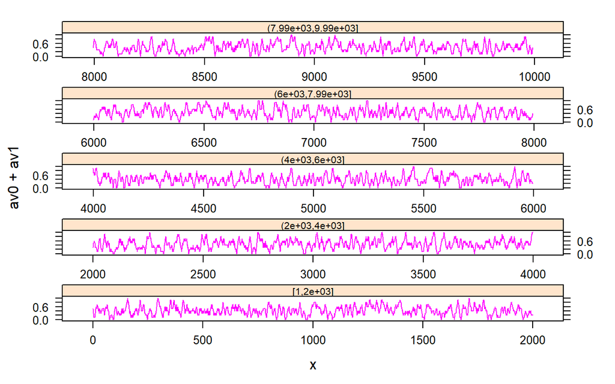

```r
library(zoo)
library(lattice)

plotmarkov <- function(n=10000, start=0, window=100, transition=Pb, npanels=5){
      xc2 <- Markov(n, start, transition)
      mav0 <- rollmean(as.integer(xc2==0), window)
      mav1 <- rollmean(as.integer(xc2==0), window)
      npanel <- cut(1:length(mav0), breaks=seq(from=1, to=length(mav0),
      length=npanels+1), include.lowest=TRUE)
      df <- data.frame(av0=mav0, av1=mav1, x=1:length(mav0),
      gp=npanel)
      print(xyplot(av0+av1 ~ x | gp, data=df, layout=c(1,npanels),
      type="l", par.strip.text=list(cex=0.65),
      scales=list(x=list(relation="free"))))
}
plotmarkov(window = 10)
```

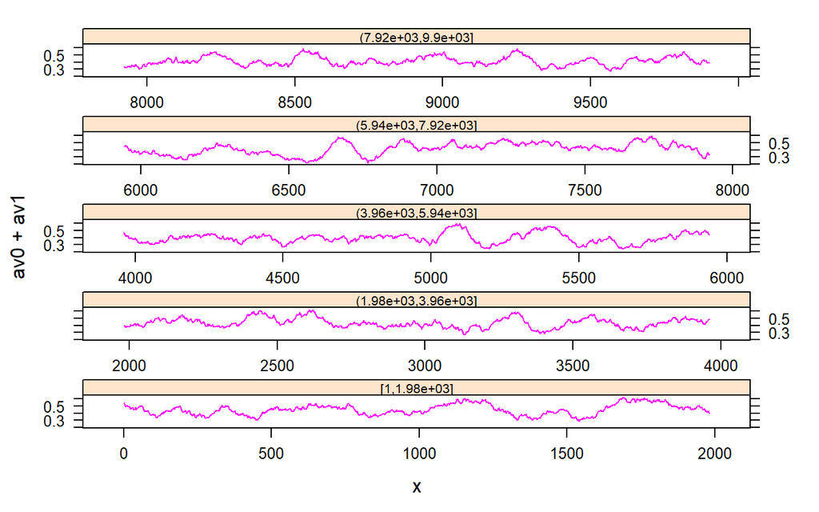

```r
plotmarkov(window = 100)
```

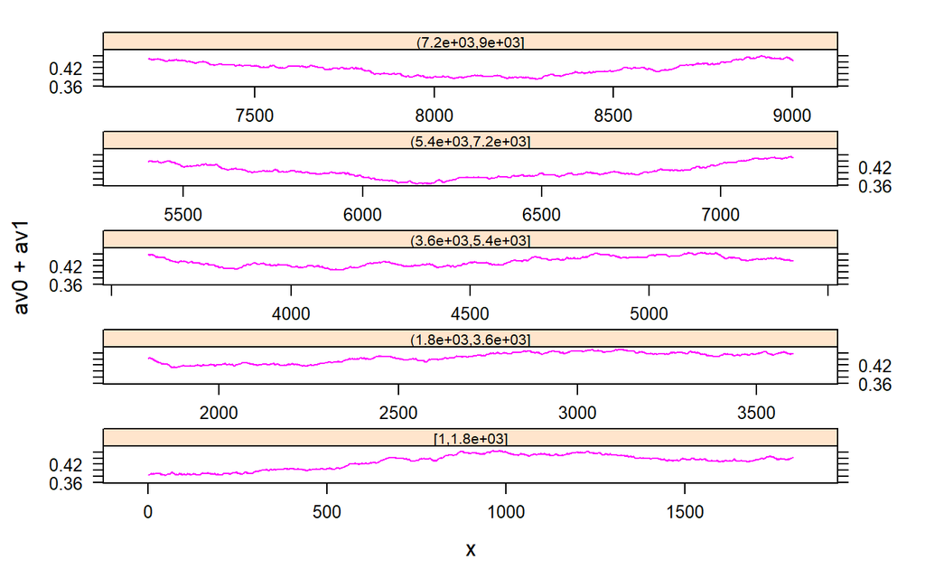

```r
plotmarkov(window = 1000)
```

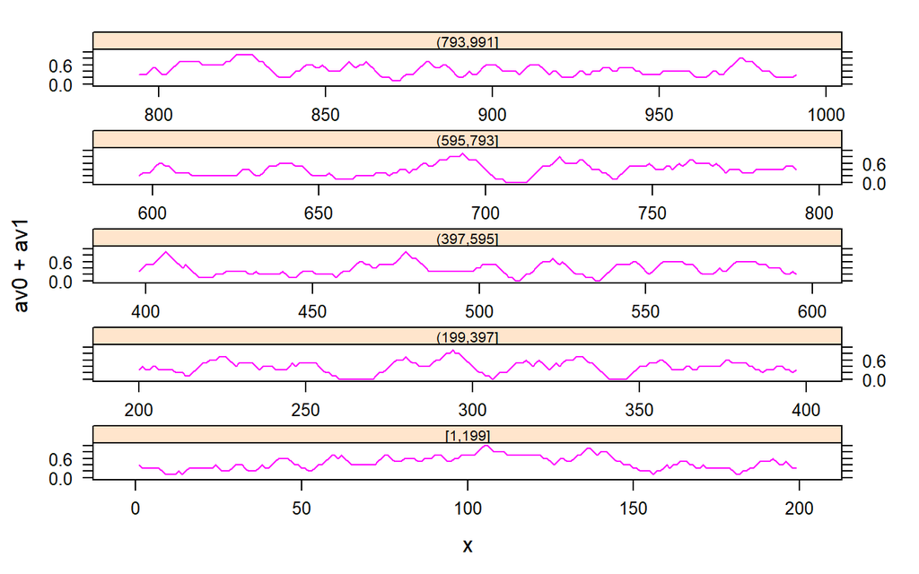

```r
plotmarkov(n=1000, window = 10)
```

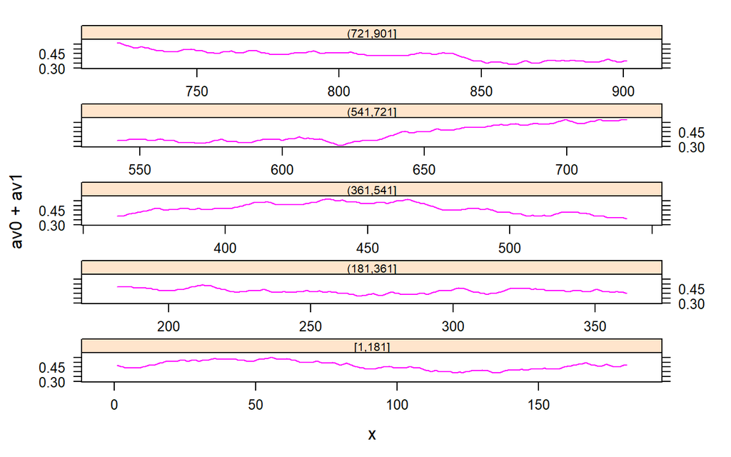

```r
plotmarkov(n=1000, window = 100)
```

### CH4.Exercise 6

Here we generate random normal numbers with a sequential dependence structure:

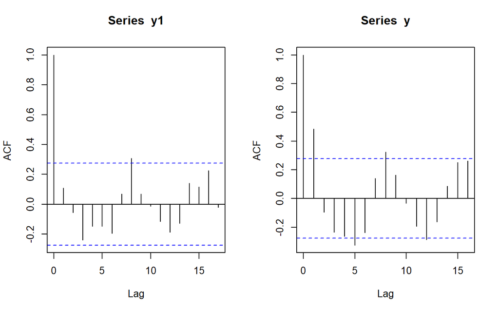

```r
y1 <- rnorm(51)
y <- y1[-1] + y1[-51]
par (mfrow=c(1,2))
acf(y1) # acf is ‘autocorrelation function
acf(y)
```

Repeat this several times. There should be no consistent pattern in the acf plot for different random samples y1. There will be a fairly consistent pattern in the acf plot for y, a result of the correlation that is introduced by adding to each value the next value in the sequence.

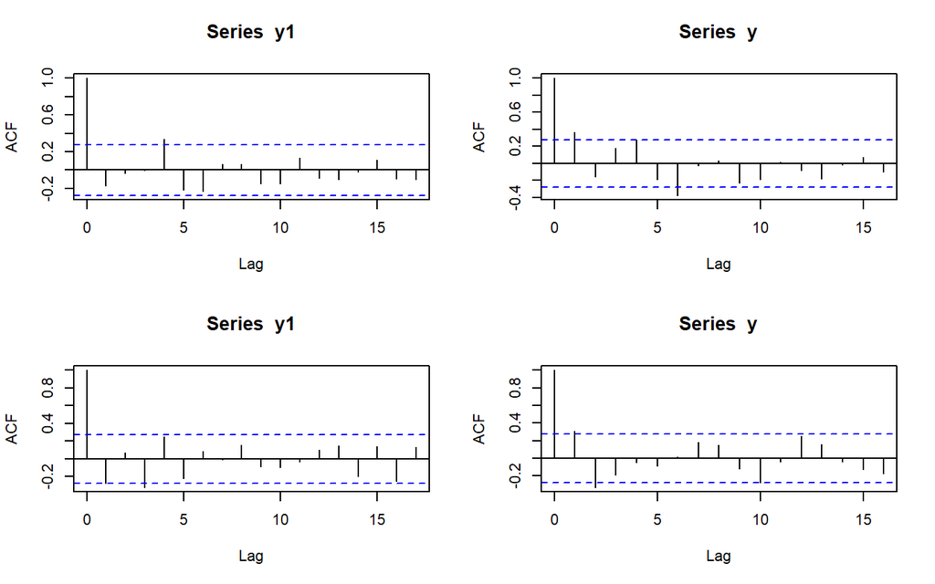

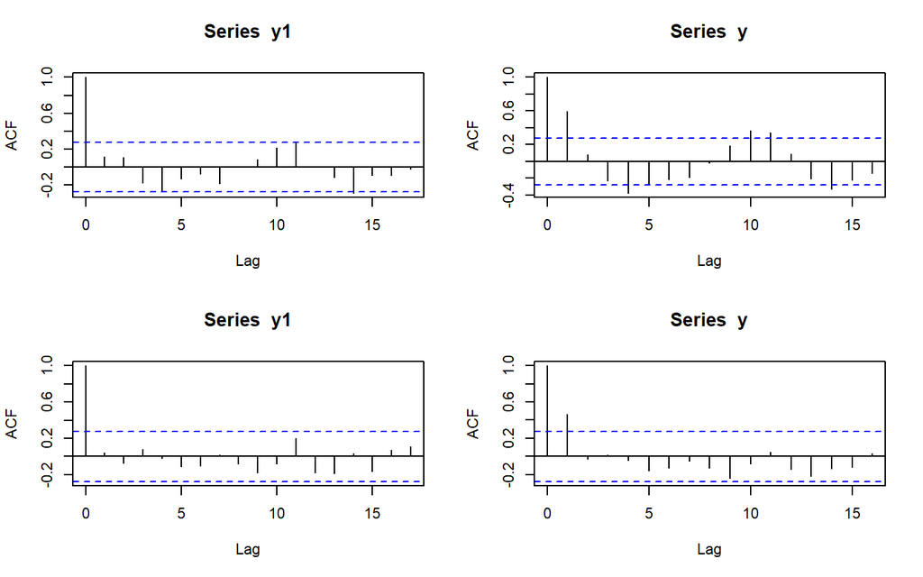

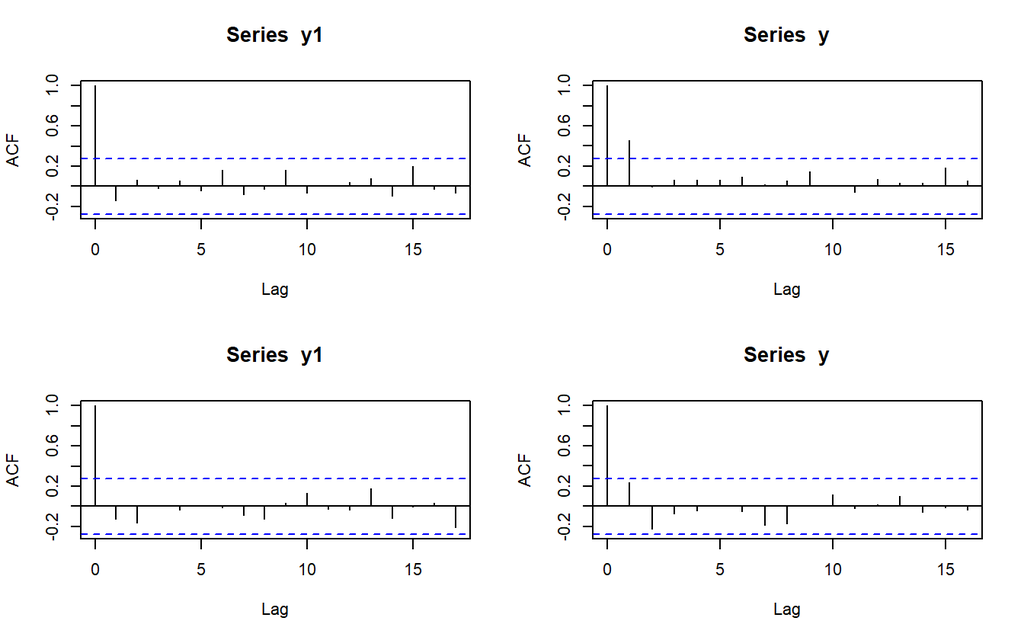

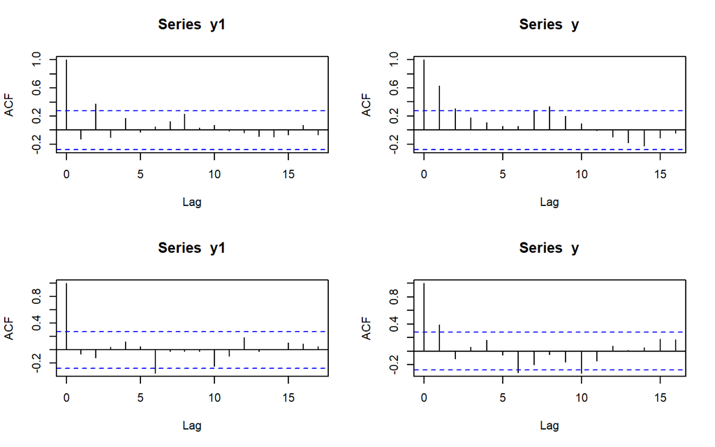

```r
par(mfrow=c(2,2))

for (i in 1:8){
  y1 <- rnorm(51)
  y <- y1[-1] + y1[-51]
  acf(y1)
  acf(y)}
```

### CH4.Exercise 7

Create a function that does the calculations in the first two lines of the previous exercise. Put the calculation in a loop that repeats 25 times. Calculate the mean and variance for each vector y that is returned. Store the 25 means in the vector av, and store the 25 variances in the vector v. Calculate the variance of av.

*solution :*

```r
set.seed(101)
auto_cor <- function(){
  y1 <- rnorm(51) # this is iid
  y <- y1[-1] + y1[-51] #this is not iid, correlated
  y
}
av <- numeric(25)
v <- numeric(25)
for (j in 1:25){
  y <- auto_cor()
  av[j] <- mean(y)
  v[j] <- var(y)
}

var(av)
```

```
## [1] 0.07163623
```

```r
mean(v)/25
```

```
## [1] 0.07363655
```